##### Θεοδώρα Χατζοπούλου

##### Εξόρυξη και Ανάλυση Δεδομένων Μεγάλου Όγκου

##### 2021-2022

# **Ανίχνευση Ψευδών Ειδήσεων με Χρήση Μηχανικής Μάθησης**

## **Το πρόβλημα της διάδοσης ψευδών ειδήσεων**

Σήμερα, σε μια εποχή όπου η πληροφορία έχει αποκτήσει βαρύνοντα ρόλο στη διαμόρφωση των κοινωνικών, οικονομικών και πολιτικών εξελίξεων, το διαδίκτυο αποτελεί μια από τις πιο διαδεδομένες πηγές πληροφόρησης. Παράγοντες όπως η ευκολία χρήσης, το χαμηλό κόστος και η ελευθερία έκφρασης στο διαδικτυακό χώρο αποτέλεσαν βασικές συνιστώσες στην εδραίωσή του ως κυρίαρχο μέσο ενημέρωσης. Ταυτόχρονα, όμως, οι ίδιοι παράγοντες συντέλεσαν στην μετατροπή του σε πρόσφορο έδαφος για τη, σκόπιμη ή μη, διάδοση ψευδών ειδήσεων, η οποία μπορεί να οφείλεται είτε σε ακούσια αναμετάδοση ελλειπώς τεκμηριωμένων πληροφοριών, είτε σε μια εσκεμμένη προσπάθεια προσέλκυσης αναγνωστικού κοινού και χειραγώγησης της κοινής γνώμης. Η άμβλυνση του φαινομένου της παραπληροφόρησης στο διαδίκτυο είναι ιδιαιτέρως δύσκολη, εξαιτίας του τεράστιου όγκου πληροφοριών που δημοσιεύονται καθημερινά από εκατομμύρια χρήστες. Ως εκ τούτου, καθίσταται σαφές, πως η ανάπτυξη αυτοματοποιημένων μεθόδων για την εκτίμηση της εγκυρότητας των ειδήσεων προβάλλει ως επιτακτική ανάγκη.

## **Υλοποίηση**

### **Φόρτωση Βιβλιοθηκών**

```r
options(java.parameters = "-Xmx6g")
options(warn=-1)
suppressPackageStartupMessages(library("tm"))
suppressPackageStartupMessages(library("ggplot2"))
suppressPackageStartupMessages(library("tidytext"))
suppressPackageStartupMessages(library("wordcloud"))
suppressPackageStartupMessages(library("tidyverse"))
suppressPackageStartupMessages(library("knitr"))
suppressPackageStartupMessages(library("caret"))
suppressPackageStartupMessages(library("RWeka"))
suppressPackageStartupMessages(library("data.table"))
suppressPackageStartupMessages(library("e1071"))
suppressPackageStartupMessages(library("randomForest"))
```

### **Φόρτωση Δεδομένων**

```r
real_news <- read.csv("X:/True.csv", stringsAsFactors=FALSE)
fake_news <- read.csv("X:/Fake.csv", stringsAsFactors=FALSE)
```

### **Οπτικοποίηση και Προεπεξεργασία Δεδομένων**

```r
kable(real_news[1:3, ], caption ="Real News")
```

Real News

| title | text | subject | date |
| --- | --- | --- | --- |
| As U.S. budget fight looms, Republicans flip their fiscal script | WASHINGTON (Reuters) - The head of a conservative Republican faction in the U.S. Congress, who voted this month for a huge expansion of the national debt to pay for tax cuts, called himself a “fiscal … | politicsNews | December 31, 2017 |
| U.S. military to accept transgender recruits on Monday: Pentagon | WASHINGTON (Reuters) - Transgender people will be allowed for the first time to enlist in the U.S. military starting on Monday as ordered by federal courts, the Pentagon said on Friday, after Presiden… | politicsNews | December 29, 2017 |
| Senior U.S. Republican senator: ‘Let Mr. Mueller do his job’ | WASHINGTON (Reuters) - The special counsel investigation of links between Russia and President Trump’s 2016 election campaign should continue without interference in 2018, despite calls from some Trum… | politicsNews | December 31, 2017 |

```r
kable(fake_news[1:3, ], caption ="Fake News")
```

Fake News

| title | text | subject | date |
| --- | --- | --- | --- |
| Donald Trump Sends Out Embarrassing New Year’s Eve Message; This is Disturbing | Donald Trump just couldn t wish all Americans a Happy New Year and leave it at that. Instead, he had to give a shout out to his enemies, haters and the very dishonest fake news media. The former reali… | News | December 31, 2017 |
| Drunk Bragging Trump Staffer Started Russian Collusion Investigation | House Intelligence Committee Chairman Devin Nunes is going to have a bad day. He s been under the assumption, like many of us, that the Christopher Steele-dossier was what prompted the Russia investig… | News | December 31, 2017 |
| Sheriff David Clarke Becomes An Internet Joke For Threatening To Poke People ‘In The Eye’ | On Friday, it was revealed that former Milwaukee Sheriff David Clarke, who was being considered for Homeland Security Secretary in Donald Trump s administration, has an email scandal of his own.In Jan… | News | December 30, 2017 |

```r
# Προσθήκη ετικέτας
real_news["target"] <- 1
fake_news["target"] <- 0

# Ένωση Συνόλων Δεδομένων
news <- rbind(real_news, fake_news)

kable(news[1:3, ], caption ="News")
```

News

| title | text | subject | date | target |
| --- | --- | --- | --- | --- |
| As U.S. budget fight looms, Republicans flip their fiscal script | WASHINGTON (Reuters) - The head of a conservative Republican faction in the U.S. Congress, who voted this month for a huge expansion of the national debt to pay for tax cuts, called himself a “fiscal … | politicsNews | December 31, 2017 | 1 |
| U.S. military to accept transgender recruits on Monday: Pentagon | WASHINGTON (Reuters) - Transgender people will be allowed for the first time to enlist in the U.S. military starting on Monday as ordered by federal courts, the Pentagon said on Friday, after Presiden… | politicsNews | December 29, 2017 | 1 |
| Senior U.S. Republican senator: ‘Let Mr. Mueller do his job’ | WASHINGTON (Reuters) - The special counsel investigation of links between Russia and President Trump’s 2016 election campaign should continue without interference in 2018, despite calls from some Trum… | politicsNews | December 31, 2017 | 1 |

```r
# Διαστάσεις Συνόλου Ειδήσεων
dim(news)
```

```
## [1] 44898     5
```

```r
# Έλεγχος για Ελλιπείς Τιμές
sum(is.na(data))
```

```
## [1] 0
```

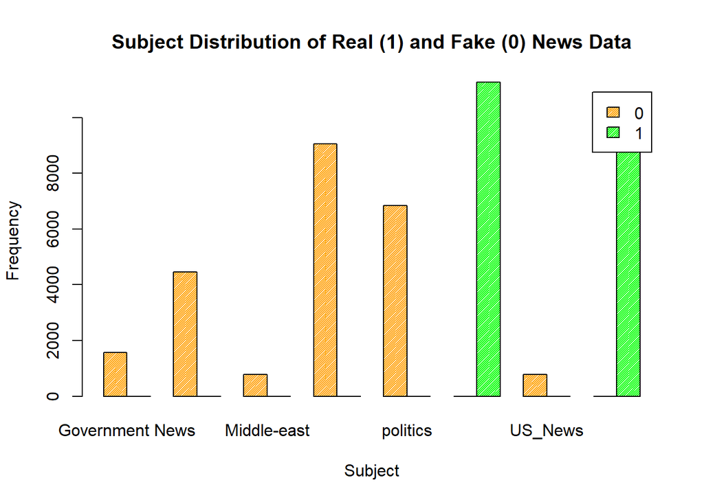

```r
# Κατανομή Θεμάτων σε Αληθείς και Ψευδείς Ειδήσεις
subject <- news$subject
target <- news$target

barplot(table(target,subject),
        main = "Subject Distribution of Real (1) and Fake (0) News Data",
        xlab = "Subject", ylab = "Frequency",
        density=65,
        col = c("orange", "green"),
        legend.text = rownames(table(target,subject)),
        beside = TRUE)
```

```r
# Αφαίρεση των Γνωρισμάτων "Θέμα" και "Ημερομηνία"
news <- subset(news, select = -c(subject, date))

colnames(news)
```

```
## [1] "title"  "text"   "target"
```

```r
# Συγχώνευση των Τίτλων με το Κείμενο
news$txt <- paste(news$title, news$text, sep=" ")
real_news$txt <- paste(real_news$title, real_news$text, sep=" ")
fake_news$txt <- paste(fake_news$title, fake_news$text, sep=" ")

news <- news[c("txt", "target")]
real_news <- real_news[c("txt")]
fake_news <- fake_news[c("txt")]

news$target <- as.factor(news$target)
news$txt <- as.character(news$txt)
real_news$txt <- as.character(real_news$txt)
fake_news$txt <- as.character(fake_news$txt)
str(news)
```

```
## 'data.frame':    44898 obs. of  2 variables:
##  $ txt   : chr  "As U.S. budget fight looms, Republicans flip their fiscal script WASHINGTON (Reuters) - The head of a conservat"| __truncated__ "U.S. military to accept transgender recruits on Monday: Pentagon WASHINGTON (Reuters) - Transgender people will"| __truncated__ "Senior U.S. Republican…
##  $ target: Factor w/ 2 levels "0","1": 2 2 2 2 2 2 2 2 2 2 ...
```

```r
str(real_news)
```

```
## 'data.frame':    21417 obs. of  1 variable:
##  $ txt: chr  "As U.S. budget fight looms, Republicans flip their fiscal script WASHINGTON (Reuters) - The head of a conservat"| __truncated__ "U.S. military to accept transgender recruits on Monday: Pentagon WASHINGTON (Reuters) - Transgender people will"| __truncated__ "Senior U.S. Republican se…
```

```r
str(fake_news)
```

```
## 'data.frame':    23481 obs. of  1 variable:
##  $ txt: chr  " Donald Trump Sends Out Embarrassing New Year’s Eve Message; This is Disturbing Donald Trump just couldn t wish"| __truncated__ " Drunk Bragging Trump Staffer Started Russian Collusion Investigation House Intelligence Committee Chairman Dev"| __truncated__ " Sheriff David Clarke Bec…
```

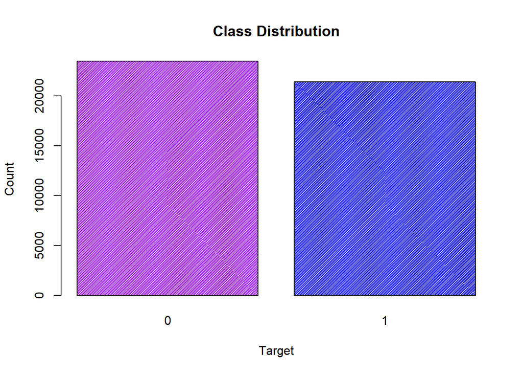

```r
# Έλεγχος αν το Σύνολο Δεδομένων είναι Ισορροπημένο
barplot(table(target),
        main = "Class Distribution",
        xlab = "Target",
        ylab = "Count",
        density=65,
        col = c("purple", "blue") )
```

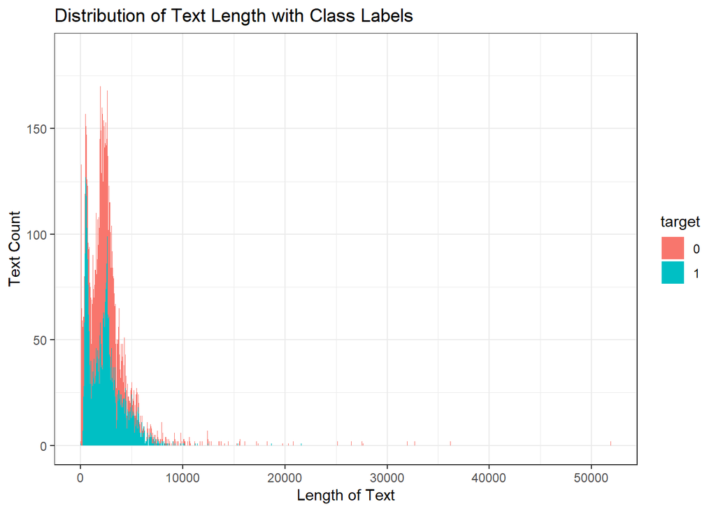

```r
# Δημιουργία στήλης που αποθηκεύει τον αριθμό των χαρακτήρων κάθε άρθρου
news$textLength <- nchar(news$txt)

# Ιστόγραμμα με το μήκος του κειμένου σε αληθείς και ψευδείς ειδήσεις
ggplot(news, aes(x= textLength, fill = target)) +
  theme_bw()+
  geom_histogram(binwidth = 10)+
  labs(y= "Text Count", x= "Length of Text", title = "Distribution of Text Length with Class Labels")
```

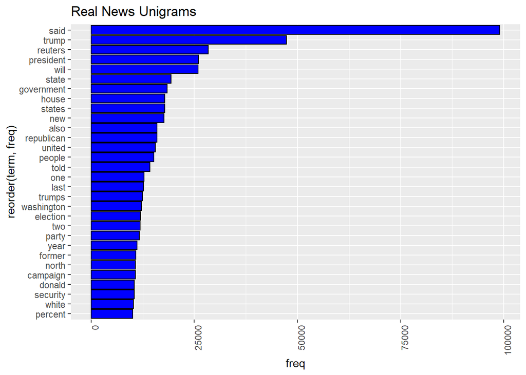

```r
real_corpus <- VCorpus(VectorSource(real_news));
fake_corpus <- VCorpus(VectorSource(fake_news));


# Καθαρισμός Ψευδών Ειδήσεων
fake_corpus <- tm_map(fake_corpus, content_transformer(tolower))
fake_corpus <- tm_map(fake_corpus, removePunctuation)
removeURL <- function(x) gsub("http[^[:space:]]*", "", x)
fake_corpus <- tm_map(fake_corpus, content_transformer(removeURL))
removeNumPunct <- function(x) gsub("[^[:alpha:][:space:]]*", "", x)
fake_corpus <- tm_map(fake_corpus, content_transformer(removeNumPunct))
fake_corpus <- tm_map(fake_corpus, stripWhitespace)
fake_corpus <- tm_map(fake_corpus, removeWords, stopwords("english"))

# Καθαρισμός Έγκυρων Ειδήσεων
real_corpus <- tm_map(real_corpus, content_transformer(tolower))
real_corpus <- tm_map(real_corpus, removePunctuation)
removeURL <- function(x) gsub("http[^[:space:]]*", "", x)
real_corpus <- tm_map(real_corpus, content_transformer(removeURL))
removeNumPunct <- function(x) gsub("[^[:alpha:][:space:]]*", "", x)
real_corpus <- tm_map(real_corpus, content_transformer(removeNumPunct))
real_corpus <- tm_map(real_corpus, stripWhitespace)
real_corpus <- tm_map(real_corpus, removeWords, stopwords("english") )

# Συναρτήσεις για Ngrams
uniTok <- function(x) NGramTokenizer(x, Weka_control(min=1, max=1))
biTok <- function(x) NGramTokenizer(x, Weka_control(min=2, max=2))
triTok <- function(x) NGramTokenizer(x, Weka_control(min=3, max=3))

# Unigrams για Αληθείς Ειδήσεις
unigram_tdm_real <- TermDocumentMatrix(real_corpus,control = list(tokenize = uniTok))
unigram_term_freq_real <- rowSums(as.matrix(unigram_tdm_real))
unigram_term_freq_vector_real <- as.list(unigram_term_freq_real)

unigrams_real <- data.frame(unlist(unigram_term_freq_vector_real), stringsAsFactors = FALSE)
setDT(unigrams_real, keep.rowname =TRUE)
setnames(unigrams_real, 1, "term")
setnames(unigrams_real, 2, "freq")
unigrams_real <- head(arrange(unigrams_real,desc(freq)), n =30 )
unigrams_real$npstype <- "unigrams_real"

ggplot(data=unigrams_real, aes(x=reorder(term,freq), y=freq)) +
  geom_bar(stat="identity",fill="blue", colour="black") +
  theme(axis.text.x = element_text(angle = 90, hjust = 1)) + coord_flip() + ggtitle("Real News Unigrams")
```

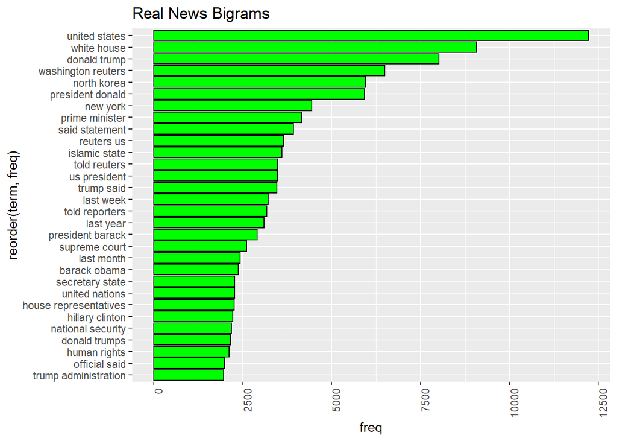

```r
# Bigrams για Αληθείς Ειδήσεις
bigram_tdm_real <- TermDocumentMatrix(real_corpus,control = list(tokenize = biTok))
bigram_term_freq_real <- rowSums(as.matrix(bigram_tdm_real))
bigram_term_freq_vector_real <- as.list(bigram_term_freq_real)

bigrams_real <- data.frame(unlist(bigram_term_freq_vector_real), stringsAsFactors = FALSE)
setDT(bigrams_real, keep.rowname =TRUE)
setnames(bigrams_real, 1, "term")
setnames(bigrams_real, 2, "freq")
bigrams_real <- head(arrange(bigrams_real,desc(freq)), n =30 )
bigrams_real$npstype <- "bigrams_real"

ggplot(data=bigrams_real, aes(x=reorder(term,freq), y=freq)) +
   geom_bar(stat="identity",fill="green", colour="black") +
   theme(axis.text.x = element_text(angle = 90, hjust = 1)) + coord_flip() + ggtitle("Real News Bigrams")
```

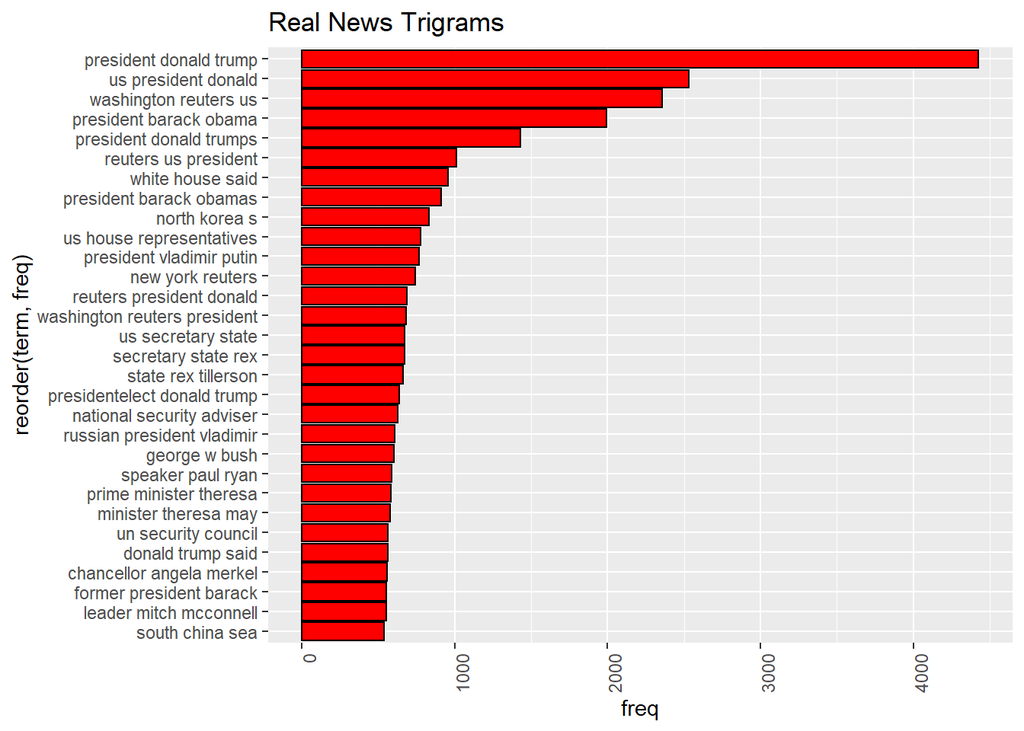

```r
# Trigrams για Αληθείς Ειδήσεις
trigram_tdm_real <- TermDocumentMatrix(real_corpus,control = list(tokenize = triTok))
trigram_term_freq_real <- rowSums(as.matrix(trigram_tdm_real))
trigram_term_freq_vector_real <- as.list(trigram_term_freq_real)

trigrams_real <- data.frame(unlist(trigram_term_freq_vector_real), stringsAsFactors = FALSE)
setDT(trigrams_real, keep.rowname =TRUE)
setnames(trigrams_real, 1, "term")
setnames(trigrams_real, 2, "freq")
trigrams_real <- head(arrange(trigrams_real,desc(freq)), n =30 )
trigrams_real$npstype <- "trigrams_real"

ggplot(data=trigrams_real, aes(x=reorder(term,freq), y=freq)) +
  geom_bar(stat="identity",fill="red", colour="black") +
  theme(axis.text.x = element_text(angle = 90, hjust = 1)) + coord_flip() + ggtitle("Real News Trigrams")
```

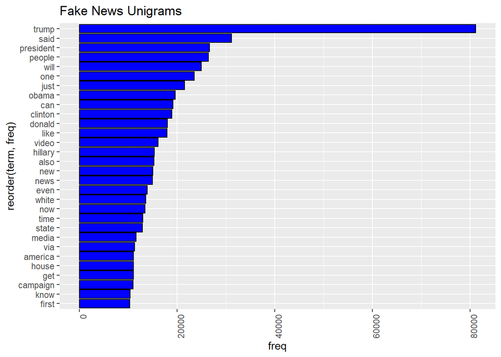

```r
# Unigrams για Ψευδείς Ειδήσεις
unigram_tdm_fake <- TermDocumentMatrix(fake_corpus,control = list(tokenize = uniTok))
unigram_term_freq_fake <- rowSums(as.matrix(unigram_tdm_fake))
unigram_term_freq_vector_fake <- as.list(unigram_term_freq_fake)

unigrams_fake <- data.frame(unlist(unigram_term_freq_vector_fake), stringsAsFactors = FALSE)
setDT(unigrams_fake, keep.rowname =TRUE)
setnames(unigrams_fake, 1, "term")
setnames(unigrams_fake, 2, "freq")
unigrams_fake <- head(arrange(unigrams_fake,desc(freq)), n =30 )
unigrams_fake$npstype <- "unigrams_fake"

ggplot(data=unigrams_fake, aes(x=reorder(term,freq), y=freq)) +
  geom_bar(stat="identity",fill="blue", colour="black") +
  theme(axis.text.x = element_text(angle = 90, hjust = 1)) + coord_flip() + ggtitle("Fake News Unigrams")
```

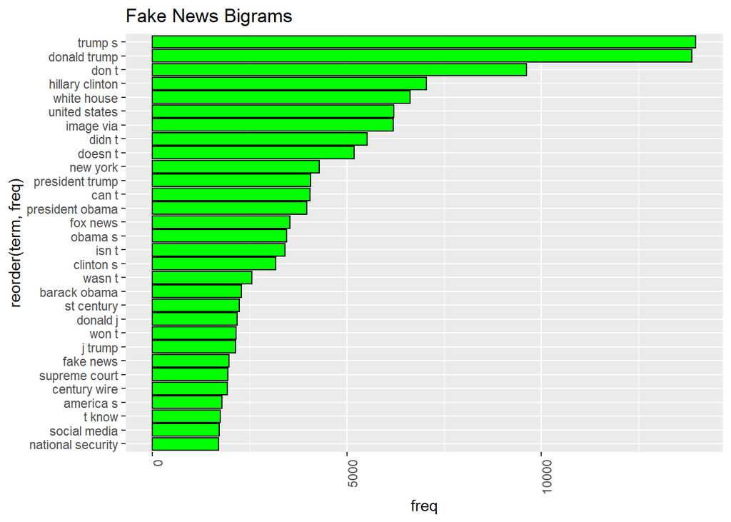

```r
# Bigrams για Ψευδείς Ειδήσεις
bigram_tdm_fake <- TermDocumentMatrix(fake_corpus,control = list(tokenize = biTok))
bigram_term_freq_fake <- rowSums(as.matrix(bigram_tdm_fake))
bigram_term_freq_vector_fake <- as.list(bigram_term_freq_fake)

bigrams_fake <- data.frame(unlist(bigram_term_freq_vector_fake), stringsAsFactors = FALSE)
setDT(bigrams_fake, keep.rowname =TRUE)
setnames(bigrams_fake, 1, "term")
setnames(bigrams_fake, 2, "freq")
bigrams_fake <- head(arrange(bigrams_fake,desc(freq)), n =30 )
bigrams_fake$npstype <- "bigrams_fake"

ggplot(data=bigrams_fake, aes(x=reorder(term,freq), y=freq)) +
   geom_bar(stat="identity",fill="green", colour="black") +
   theme(axis.text.x = element_text(angle = 90, hjust = 1)) + coord_flip() + ggtitle("Fake News Bigrams")
```

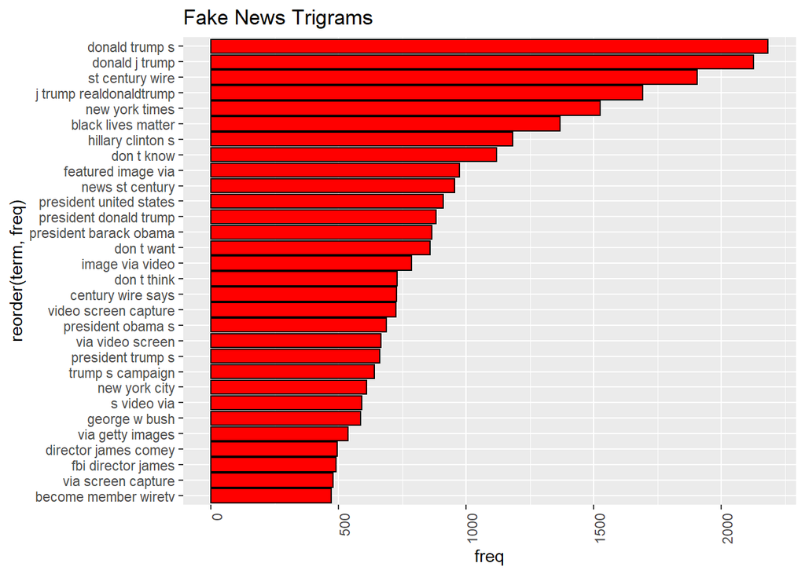

```r
# Trigrams για Ψευδείς Ειδήσεις
trigram_tdm_fake <- TermDocumentMatrix(fake_corpus,control = list(tokenize = triTok))
trigram_term_freq_fake <- rowSums(as.matrix(trigram_tdm_fake))
trigram_term_freq_vector_fake <- as.list(trigram_term_freq_fake)

trigrams_fake <- data.frame(unlist(trigram_term_freq_vector_fake), stringsAsFactors = FALSE)
setDT(trigrams_fake, keep.rowname =TRUE)
setnames(trigrams_fake, 1, "term")
setnames(trigrams_fake, 2, "freq")
trigrams_fake <- head(arrange(trigrams_fake,desc(freq)), n =30 )
trigrams_fake$npstype <- "trigrams_real"

ggplot(data=trigrams_fake, aes(x=reorder(term,freq), y=freq)) +
  geom_bar(stat="identity",fill="red", colour="black") +
  theme(axis.text.x = element_text(angle = 90, hjust = 1)) + coord_flip() + ggtitle("Fake News Trigrams")
```

[figure not shown]

```r
# Κατασκευή dtm για Αληθείς Ειδήσεις
dtm_real <- TermDocumentMatrix(real_corpus)
dtm_matrix_real <- as.matrix(dtm_real)
words <- sort(rowSums(dtm_matrix_real),decreasing=TRUE)
real_df <- data.frame(word = names(words),freq=words)

# Wordcloud για Αληθείς Ειδήσεις
set.seed(1234)
wordcloud(words = real_df$word, freq = real_df$freq, min.freq = 1, max.words=200, rot.per=.35, random.order=FALSE, scale=c(3.5,0.2), colors=brewer.pal(8, "Dark2") )
```

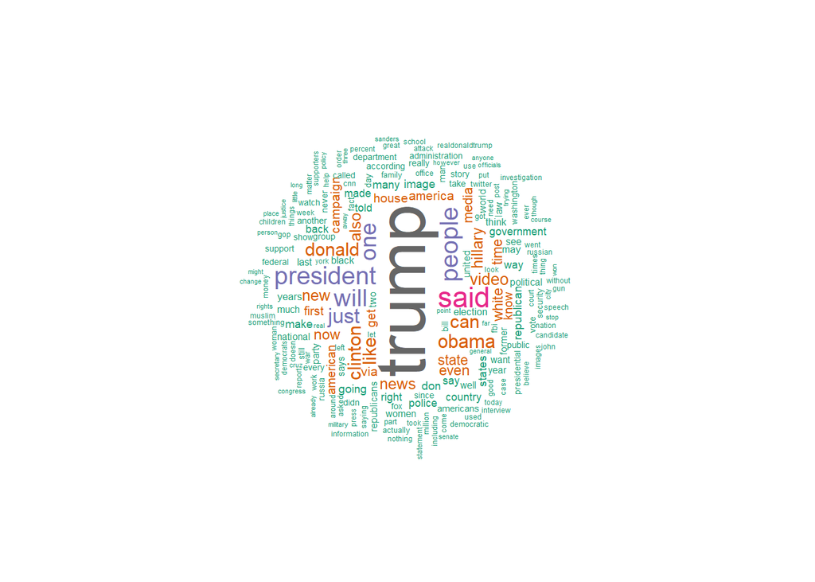

```r
# Κατασκευή dtm για Ψευδείς Ειδήσεις
dtm_fake <- TermDocumentMatrix(fake_corpus)
dtm_matrix_fake <- as.matrix(dtm_fake)
words <- sort(rowSums(dtm_matrix_fake),decreasing=TRUE)
fake_df <- data.frame(word = names(words),freq=words)

# Wordcloud για Ψευδείς Ειδήσεις
set.seed(1234)
wordcloud(words = fake_df$word, freq =fake_df$freq, min.freq = 1, max.words=200, rot.per=.35, random.order=FALSE, scale=c(3.5,0.2), colors=brewer.pal(8, "Dark2") )
```

### **Εκπαίδευση Ταξινομητών**

```r
# Διαχωρισμός Δεδομένων σε Σύνολο Εκπαίδευσης και Ελέγχου
i <- createDataPartition(y = news$target, times = 1, p = 0.8, list = FALSE)
training_set <- news[i,]
test_set <- news[-i,]

# Δημιουργία corpus για Σύνολο Εκπαίδεσυης και Ελέγχου
train_corpus <- VCorpus(VectorSource(training_set$txt))
test_corpus <- VCorpus(VectorSource(test_set$txt))

# Καθαρισμός corpus Συνόλου Εκπαίδεσυης και Ελέγχου
train_corpus <- tm_map(train_corpus, content_transformer(tolower))
removeURL <- function(x) gsub("http[^[:space:]]*", "", x)
train_corpus <- tm_map(train_corpus, content_transformer(removeURL))
train_corpus <- tm_map(train_corpus, removeNumbers)
train_corpus <- tm_map(train_corpus, removePunctuation)
train_corpus <- tm_map(train_corpus, stripWhitespace)
train_corpus <- tm_map(train_corpus, removeWords, stopwords("english"))
train_corpus <- tm_map(train_corpus, stemDocument)

test_corpus <- tm_map(test_corpus, content_transformer(tolower))
test_corpus <- tm_map(test_corpus, content_transformer(removeURL))
test_corpus <- tm_map(test_corpus, removeNumbers)
test_corpus <- tm_map(test_corpus, removePunctuation)
test_corpus <- tm_map(test_corpus, stripWhitespace)
test_corpus <- tm_map(test_corpus, removeWords, stopwords("english"))
test_corpus <- tm_map(test_corpus, stemDocument)

# Δημιουργία dtm για Σύνολο Εκπαίδευσης και Μετατροπή σε Dataframe
dtm_train <- DocumentTermMatrix(train_corpus)
train_corpus <- removeSparseTerms(dtm_train, 0.9)
dtm_train_matrix <- as.matrix(train_corpus)
training_set_df <- as.data.frame(dtm_train_matrix)
names(training_set_df) <- make.names(names(training_set_df))

# Δημιουργία dtm για Σύνολο Ελέγχου και Μετατροπή σε Dataframe
dtm_test <- DocumentTermMatrix(test_corpus, control = list(dictionary = Terms(dtm_train)))
test_corpus <- removeSparseTerms(dtm_test, 0.9)
dtm_test_matrix <- as.matrix(test_corpus)
test_set_df <- as.data.frame(dtm_test_matrix)
names(test_set_df) <- make.names(names(test_set_df))

# Αφαίρεση μη Κοινών Στηλών
d <- intersect(names(training_set_df), names(test_set_df))
names_use_test <- names(test_set_df)[(names(test_set_df) %in% d)]
test_set_df.subset <- test_set_df[, names_use_test]

names_use_train <- names(training_set_df)[(names(training_set_df) %in% d)]
training_set_df.subset <- training_set_df[, names_use_train ]
training_set_df.subset$target <- training_set$target
training_set_df.subset$target <- as.factor(training_set_df.subset$target)

# Εκπαίδευση Naive Bayes
nb_model <- naiveBayes(target ~ ., data = training_set_df.subset)


# Εκπαίδευση SVM με Γραμμικό Πυρήνα
svm_model <- svm(target~ ., data = training_set_df.subset, kernel = "linear", scale = FALSE)


# Εκπαίδευση Random Forest
rf_model <- randomForest(formula = target~ .,
                       data = training_set_df.subset,
                       ntree = 100,
                       mtry = round(sqrt(ncol(training_set_df)-1)),
                       method = 'class')
```

### **Αξιολόγηση Ταξινομητών**

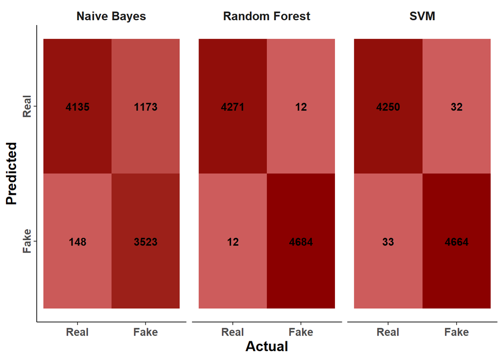

```r
# Ακρίβεια Μοντέλων στο Σύνολο Ελέγχου

# Naive Bayes
test_set_df.subset$nb_pred <- predict(nb_model, newdata = test_set_df.subset)
# SVM Linear
test_set_df.subset$svm_pred <- predict(svm_model, newdata = test_set_df.subset)
# Random Forest
test_set_df.subset$rf_pred <- predict(rf_model, newdata = test_set_df.subset)

# Πίνακας Σύγχυσης (Confusion Matrix)
nb_conf <- confusionMatrix(test_set_df.subset$nb_pred, test_set$target)
svm_conf <- confusionMatrix(test_set_df.subset$svm_pred, test_set$target)
rf_conf <- confusionMatrix(test_set_df.subset$rf_pred, test_set$target)

# Πίνακας Σύγχυσης για τους Τρεις Ταξινομητές
bind_rows(as.data.frame(nb_conf$table), as.data.frame(svm_conf$table), as.data.frame(rf_conf$table)) %>%
  mutate(Model = rep(c('Naive Bayes', 'SVM', 'Random Forest'), each = 4)) %>%
  ggplot(aes(x = Reference, y = Prediction, fill = Freq)) +
  geom_tile() +
  labs(x = 'Actual', y = 'Predicted') +
  scale_fill_gradient(low = "#CD5C5C", high = "#8B0000") +
  scale_x_discrete(limits = c('1', '0'), labels = c('1' = 'Real', '0' = 'Fake')) +
  scale_y_discrete(labels = c('1' = 'Real', '0' = 'Fake')) +
  facet_grid(. ~ Model) +
  geom_text(aes(label = Freq), fontface = 'bold') +
  theme(panel.background = element_blank(),
        legend.position = 'none',
        axis.line = element_line(colour = "black"),
        axis.title = element_text(size = 14, face = 'bold'),
        axis.text = element_text(size = 11, face = 'bold'),
        axis.text.y = element_text(angle = 90, hjust = 0.5),
        strip.background = element_blank(),
        strip.text = element_text(size = 12, face = 'bold'))
```

```r
# Ορθότητα, Ακρίβεια, Ανάκληση/Ευαισθησία και F1 Score

# Ορθότητα
accuracy_nb <- nb_conf$overall[1]
accuracy_svm <- svm_conf$overall[1]
accuracy_rf <- rf_conf$overall[1]

# Ακρίβεια
precision_nb <- posPredValue(test_set$target, test_set_df.subset$nb_pred)
precision_svm <- posPredValue(test_set$target, test_set_df.subset$svm_pred)
precision_rf <- posPredValue(test_set$target, test_set_df.subset$rf_pred)

# Ανάκληση
recall_nb <- sensitivity(test_set$target, test_set_df.subset$nb_pred)
recall_svm <- sensitivity(test_set$target, test_set_df.subset$svm_pred)
recall_rf <- sensitivity(test_set$target, test_set_df.subset$rf_pred)

# F1-Score
f1_nb <- (2 * precision_nb * recall_nb) / (precision_nb + recall_nb)
f1_svm <- (2 * precision_svm * recall_svm) / (precision_svm + recall_svm)
f1_rf <- (2 * precision_rf * recall_rf) / (precision_rf + recall_rf)

# Κατασκευή Πίνακα με Μετρικές Αξιολόγησης
acc <- c(accuracy_nb,accuracy_svm,accuracy_rf)
precision <- c(precision_nb, precision_svm, precision_rf)
recall <- c(recall_nb, recall_svm, recall_rf)
f1 <- c(f1_nb, f1_svm, f1_rf)

data.frame(Model = c('Naive Bayes', 'SVM', 'Random Forest'),
           Accuracy = acc,
           Precision = precision,
           Recall = recall,
           F1_Score = f1,
           row.names = NULL)
```

```
##           Model  Accuracy Precision    Recall  F1_Score
## 1   Naive Bayes 0.8528789 0.7502129 0.9596840 0.8421178
## 2           SVM 0.9927609 0.9931857 0.9929742 0.9930800
## 3 Random Forest 0.9973271 0.9974446 0.9974446 0.9974446
```